# Week 13 Ecommerce Project

Mr. Mutai

7/11/2021

# ASSESSMENT QUESTION

Kira Plastinina is a Russian brand that is sold through a defunct chain of retail stores in Russia, Ukraine, Kazakhstan, Belarus, China, Philippines, and Armenia. The brand’s Sales and Marketing team would like to understand their customer’s behavior from data that they have collected over the past year. More specifically, they would like to learn the characteristics of customer groups.

# 1. DEFINING THE QUESTION

## i) Defining the Specific Data Analytic Question

The brand’s Sales and Marketing team would like to understand the characteristics of customer groups in the respective countries.

## ii) Defining the Metric for Success

To be able to build unsupervised learning algorithms that will help us understand the characteristics of customer groups in our dataset.

## iii) Understanding the Context

Kira Plastinina is a Russian fashion designer and entrepreneur whose first brand store opened in Moscow, 2017. The brand has been worn by many celebrities such as Paris Hilton and Lindsay Lohan.

## iv) Recording the Experimental Design

1. Problem Definition
2. Data Sourcing
3. Check the Data
4. Perform Data Cleaning
5. Perform Exploratory Data Analysis (Univariate, Bivariate & Multivariate)
6. Implement the Solution using the unsupervised learning algorithms.
7. Challenge the Solution
8. Follow up Questions

# 2. IMPORTING THE RELEVANT LIBRARIES

```r
library(data.table)
library(ggplot2)
library(caret)
library(caretEnsemble)
library(psych)
library(Amelia)
library(mice)
library(GGally)
library(rpart)
```

# 3. DATA SOURCING

```r
commerce <- fread('http://bit.ly/EcommerceCustomersDataset')

# View the dataset in our environment
View(commerce)
```

# 4. PREVIEWING THE DATASET

1. The top 6 rows in our dataset

```r
head(commerce)
```

```
##    Administrative Administrative_Duration Informational Informational_Duration
## 1:              0                       0             0                      0
## 2:              0                       0             0                      0
## 3:              0                      -1             0                     -1
## 4:              0                       0             0                      0
## 5:              0                       0             0                      0
## 6:              0                       0             0                      0
##    ProductRelated ProductRelated_Duration BounceRates ExitRates PageValues
## 1:              1                0.000000  0.20000000 0.2000000          0
## 2:              2               64.000000  0.00000000 0.1000000          0
## 3:              1               -1.000000  0.20000000 0.2000000          0
## 4:              2                2.666667  0.05000000 0.1400000          0
## 5:             10              627.500000  0.02000000 0.0500000          0
## 6:             19              154.216667  0.01578947 0.0245614          0
##    SpecialDay Month OperatingSystems Browser Region TrafficType
## 1:          0   Feb                1       1      1           1
## 2:          0   Feb                2       2      1           2
## 3:          0   Feb                4       1      9           3
## 4:          0   Feb                3       2      2           4
## 5:          0   Feb                3       3      1           4
## 6:          0   Feb                2       2      1           3
##          VisitorType Weekend Revenue
## 1: Returning_Visitor   FALSE   FALSE
## 2: Returning_Visitor   FALSE   FALSE
## 3: Returning_Visitor   FALSE   FALSE
## 4: Returning_Visitor   FALSE   FALSE
## 5: Returning_Visitor    TRUE   FALSE
## 6: Returning_Visitor   FALSE   FALSE
```

2. The bottom 6 rows in our dataset

```r
tail(commerce)
```

```
##    Administrative Administrative_Duration Informational Informational_Duration
## 1:              0                       0             1                      0
## 2:              3                     145             0                      0
## 3:              0                       0             0                      0
## 4:              0                       0             0                      0
## 5:              4                      75             0                      0
## 6:              0                       0             0                      0
##    ProductRelated ProductRelated_Duration BounceRates  ExitRates PageValues
## 1:             16                 503.000 0.000000000 0.03764706    0.00000
## 2:             53                1783.792 0.007142857 0.02903061   12.24172
## 3:              5                 465.750 0.000000000 0.02133333    0.00000
## 4:              6                 184.250 0.083333333 0.08666667    0.00000
## 5:             15                 346.000 0.000000000 0.02105263    0.00000
## 6:              3                  21.250 0.000000000 0.06666667    0.00000
##    SpecialDay Month OperatingSystems Browser Region TrafficType
## 1:          0   Nov                2       2      1           1
## 2:          0   Dec                4       6      1           1
## 3:          0   Nov                3       2      1           8
## 4:          0   Nov                3       2      1          13
## 5:          0   Nov                2       2      3          11
## 6:          0   Nov                3       2      1           2
##          VisitorType Weekend Revenue
## 1: Returning_Visitor   FALSE   FALSE
## 2: Returning_Visitor    TRUE   FALSE
## 3: Returning_Visitor    TRUE   FALSE
## 4: Returning_Visitor    TRUE   FALSE
## 5: Returning_Visitor   FALSE   FALSE
## 6:       New_Visitor    TRUE   FALSE
```

3. The shape of the dataset

```r
dim(commerce)
```

```
## [1] 12330    18
```

Our dataset has 12330 rows and 18 columns.

4. The datatypes of the columns in our dataset

```r
str(commerce)
```

```
## Classes 'data.table' and 'data.frame':   12330 obs. of  18 variables:
##  $ Administrative         : int  0 0 0 0 0 0 0 1 0 0 ...
##  $ Administrative_Duration: num  0 0 -1 0 0 0 -1 -1 0 0 ...
##  $ Informational          : int  0 0 0 0 0 0 0 0 0 0 ...
##  $ Informational_Duration : num  0 0 -1 0 0 0 -1 -1 0 0 ...
##  $ ProductRelated         : int  1 2 1 2 10 19 1 1 2 3 ...
##  $ ProductRelated_Duration: num  0 64 -1 2.67 627.5 ...
##  $ BounceRates            : num  0.2 0 0.2 0.05 0.02 ...
##  $ ExitRates              : num  0.2 0.1 0.2 0.14 0.05 ...
##  $ PageValues             : num  0 0 0 0 0 0 0 0 0 0 ...
##  $ SpecialDay             : num  0 0 0 0 0 0 0.4 0 0.8 0.4 ...
##  $ Month                  : chr  "Feb" "Feb" "Feb" "Feb" ...
##  $ OperatingSystems       : int  1 2 4 3 3 2 2 1 2 2 ...
##  $ Browser                : int  1 2 1 2 3 2 4 2 2 4 ...
##  $ Region                 : int  1 1 9 2 1 1 3 1 2 1 ...
##  $ TrafficType            : int  1 2 3 4 4 3 3 5 3 2 ...
##  $ VisitorType            : chr  "Returning_Visitor" "Returning_Visitor" "Returning_Visitor" "Returning_Visitor" ...
##  $ Weekend                : logi  FALSE FALSE FALSE FALSE TRUE FALSE ...
##  $ Revenue                : logi  FALSE FALSE FALSE FALSE FALSE FALSE ...
##  - attr(*, ".internal.selfref")=<externalptr>
```

We have 2 logical columns, 7 numeric columns, 7 integer columns and 2 columns of the datatype character.

- Before cleaning our dataset, we can go ahead and convert the datatypes of some of our numerical columns and make them categorical for better analysis.

```r
commerce$OperatingSystems <- as.character(commerce$OperatingSystems)
commerce$Browser <- as.character(commerce$Browser)
commerce$Region <- as.character(commerce$Region)
commerce$TrafficType <- as.character(commerce$TrafficType)
```

# 5. CLEANING THE DATASET

## Checking for null values in the dataset

```r
colSums(is.na(commerce))
```

```
##          Administrative Administrative_Duration           Informational
##                      14                      14                      14
##  Informational_Duration          ProductRelated ProductRelated_Duration
##                      14                      14                      14
##             BounceRates               ExitRates              PageValues
##                      14                      14                       0
##              SpecialDay                   Month        OperatingSystems
##                       0                       0                       0
##                 Browser                  Region             TrafficType
##                       0                       0                       0
##             VisitorType                 Weekend                 Revenue
##                       0                       0                       0
```

From the code above, we can tell that we have 14 missing values in each of the following 8 columns namely : “Administrative”, “Administrative_Duration”, “Informational”, “Informational_Duration”, “ProductRelated”, “ProductRelated_Duration”, “BounceRates” and “ExitRates”.

### Dealing with the missing values in our dataset

```r
com <- na.omit(commerce)
dim(commerce)
```

```
## [1] 12330    18
```

```r
dim(com)
```

```
## [1] 12316    18
```

We decided to omit the missing values from our initial dataset and use the new dataset for analysis and modelling.

## Checking for duplicated rows in our dataset

```r
duplicated_rows <- com[(duplicated(com))]
duplicated_rows
```

```
##      Administrative Administrative_Duration Informational
##   1:              0                       0             0
##   2:              0                       0             0
##   3:              0                       0             0
##   4:              0                       0             0
##   5:              0                       0             0
##  ---
## 113:              0                       0             0
## 114:              0                       0             0
## 115:              0                       0             0
## 116:              0                       0             0
## 117:              0                       0             0
##      Informational_Duration ProductRelated ProductRelated_Duration BounceRates
##   1:                      0              1                       0         0.2
##   2:                      0              1                       0         0.2
```

[output cut: 33 more lines]

- We can tell that we have 117 duplicated rows which we will go ahead and drop them since they will distort our analysis.

### Dropping the duplicated rows

```r
# We create a new dataset that holds the unique values in our dataset
new_com <- unique(com)
dim(new_com)
```

```
## [1] 12199    18
```

- After dropping the duplicated rows, we go ahead to use the new_com dataset for analysis.

## Checking for outliers

```r
par(mfrow = c(4,3), mar = c(5,4,3,3))

# Finding all columns that are numerical/not strings & subsetting to new dataframe
#numerical_col <- new_com[, sapply(new_com, is.numeric)]

numerical_col <- subset(new_com, select = c(1,2,3,4,5,6,7,8,9,10))
num1 <- subset(new_com, select = c(1,2,3))
num2 <- subset(new_com, select = c(4,5,6))
num3 <- subset(new_com, select = c(7,8,9))
#boxplot(numerical_col, main='BoxPlots')
```

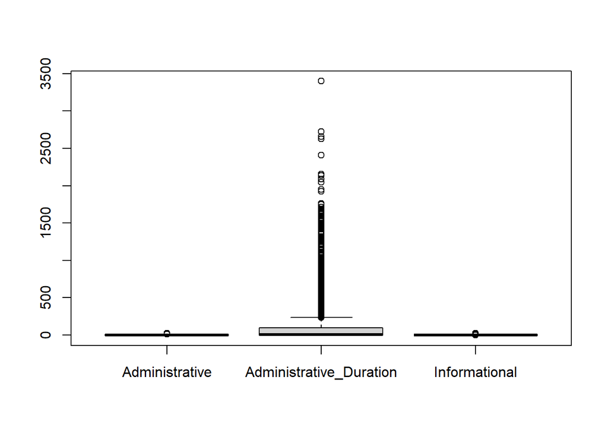

```r
boxplot(num1)
```

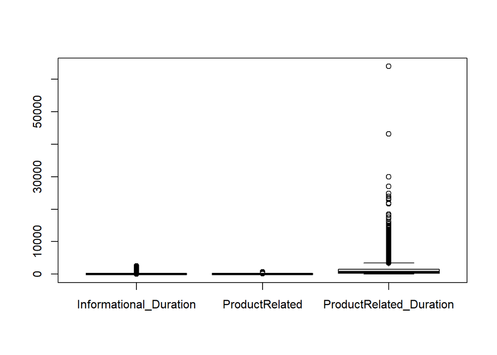

```r
boxplot(num2)
```

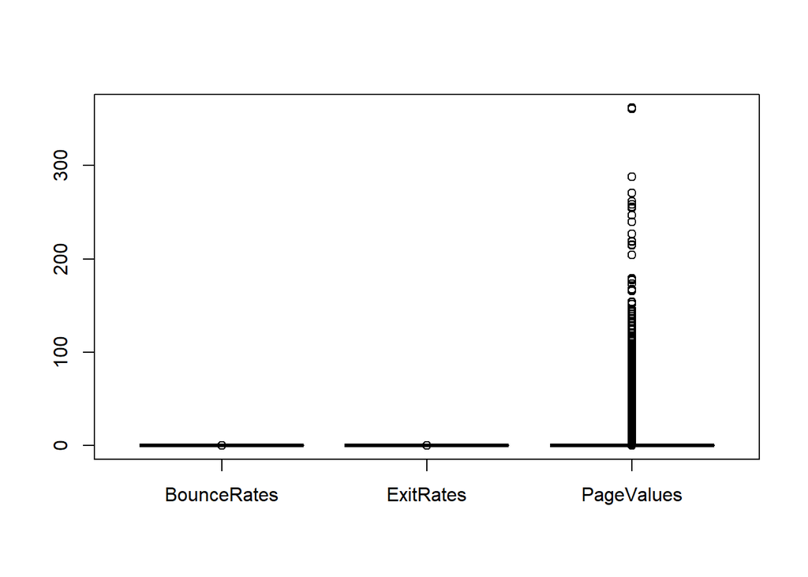

```r
boxplot(num3)
```

# 6. EXPLORATORY DATA ANALYSIS

## A. UNIVARIATE DATA ANALYSIS

### Measures of Central Tendency

#### i) Mean

```r
library(dplyr)
new_com %>% summarise_if(is.numeric, mean)
```

```
##   Administrative Administrative_Duration Informational Informational_Duration
## 1       2.340028                81.68214     0.5088122               34.83734
##   ProductRelated ProductRelated_Duration BounceRates  ExitRates PageValues
## 1       32.05845                1207.508  0.02044674 0.04149678     5.9525
##   SpecialDay
## 1 0.06197229
```

#### ii) Mode

```r
getmode <- function(v) {
  uniqv <- unique(v)
  uniqv[which.max(tabulate(match(v, uniqv)))]
}

new_com %>% summarise_if(is.numeric, getmode)
```

```
##   Administrative Administrative_Duration Informational Informational_Duration
## 1              0                       0             0                      0
##   ProductRelated ProductRelated_Duration BounceRates ExitRates PageValues
## 1              1                       0           0       0.2          0
##   SpecialDay
## 1          0
```

#### iii) Median

```r
new_com %>% summarise_if(is.numeric, median)
```

```
##   Administrative Administrative_Duration Informational Informational_Duration
## 1              1                       9             0                      0
##   ProductRelated ProductRelated_Duration BounceRates ExitRates PageValues
## 1             18                609.5417 0.002930403     0.025          0
##   SpecialDay
## 1          0
```

### Measures of Dispersion

#### i) Range

```r
new_com %>% summarise_if(is.numeric, range)
```

```
##   Administrative Administrative_Duration Informational Informational_Duration
## 1              0                   -1.00             0                 -1.000
## 2             27                 3398.75            24               2549.375
##   ProductRelated ProductRelated_Duration BounceRates ExitRates PageValues
## 1              0                   -1.00         0.0       0.0     0.0000
## 2            705                63973.52         0.2       0.2   361.7637
##   SpecialDay
## 1          0
## 2          1
```

#### ii) Quantiles

```r
new_com %>% summarise_if(is.numeric, quantile)
```

```
##   Administrative Administrative_Duration Informational Informational_Duration
## 1              0                   -1.00             0                 -1.000
## 2              0                    0.00             0                  0.000
## 3              1                    9.00             0                  0.000
## 4              4                   94.75             0                  0.000
## 5             27                 3398.75            24               2549.375
##   ProductRelated ProductRelated_Duration BounceRates  ExitRates PageValues
## 1              0                 -1.0000 0.000000000 0.00000000     0.0000
## 2              8                193.5833 0.000000000 0.01422258     0.0000
## 3             18                609.5417 0.002930403 0.02500000     0.0000
## 4             38               1477.5648 0.016666667 0.04848485     0.0000
## 5            705              63973.5222 0.200000000 0.20000000   361.7637
##   SpecialDay
## 1          0
## 2          0
## 3          0
## 4          0
## 5          1
```

#### iii) Variance

```r
new_com %>% summarise_if(is.numeric, var)
```

```
##   Administrative Administrative_Duration Informational Informational_Duration
## 1       11.09457                31516.25       1.62771               20010.51
##   ProductRelated ProductRelated_Duration BounceRates ExitRates PageValues
## 1       1989.241                 3686121 0.002061387 0.0021388   348.1132
##   SpecialDay
## 1 0.03988432
```

#### iv) Standard Deviation

```r
new_com %>% summarise_if(is.numeric, sd)
```

```
##   Administrative Administrative_Duration Informational Informational_Duration
## 1       3.330851                177.5282      1.275817               141.4585
##   ProductRelated ProductRelated_Duration BounceRates  ExitRates PageValues
## 1       44.60091                1919.927   0.0454025 0.04624716   18.65779
##   SpecialDay
## 1  0.1997106
```

### Frequency Tables

```r
month <- table(new_com$Month)
month
```

```
##
##  Aug  Dec  Feb  Jul June  Mar  May  Nov  Oct  Sep
##  433 1706  182  432  285 1853 3328 2983  549  448
```

May had the most entries in our dataset followed by November then March.

```r
os <- table(new_com$OperatingSystems)
os
```

```
##
##    1    2    3    4    5    6    7    8
## 2548 6536 2530  478    6   19    7   75
```

Operating system 2 had the most entries in our dataset.

```r
browser <- table(new_com$Browser)
browser
```

```
##
##    1   10   11   12   13    2    3    4    5    6    7    8    9
## 2426  163    6   10   56 7878  105  730  466  174   49  135    1
```

Browser 2 had the most entries in our dataset.

```r
region <- table(new_com$Region)
region
```

```
##
##    1    2    3    4    5    6    7    8    9
## 4711 1127 2382 1168  317  800  758  431  505
```

Region 1 had the most entries in our dataset.

```r
traffic <- table(new_com$TrafficType)
traffic
```

```
##
##    1   10   11   12   13   14   15   16   17   18   19    2   20    3    4    5
## 2383  450  247    1  728   13   36    3    1   10   17 3907  193 2017 1066  260
##    6    7    8    9
##  443   40  343   41
```

Traffic Type 2 had the most entries in our dataset.

```r
visitor <- table(new_com$VisitorType)
visitor
```

```
##
##       New_Visitor             Other Returning_Visitor
##              1693                81             10425
```

```r
weekend <- table(new_com$Weekend)
weekend
```

```
##
## FALSE  TRUE
##  9343  2856
```

```r
revenue <- table(new_com$Revenue)
revenue
```

```
##
## FALSE  TRUE
## 10291  1908
```

### Graphical Plots

#### i) Bar Charts

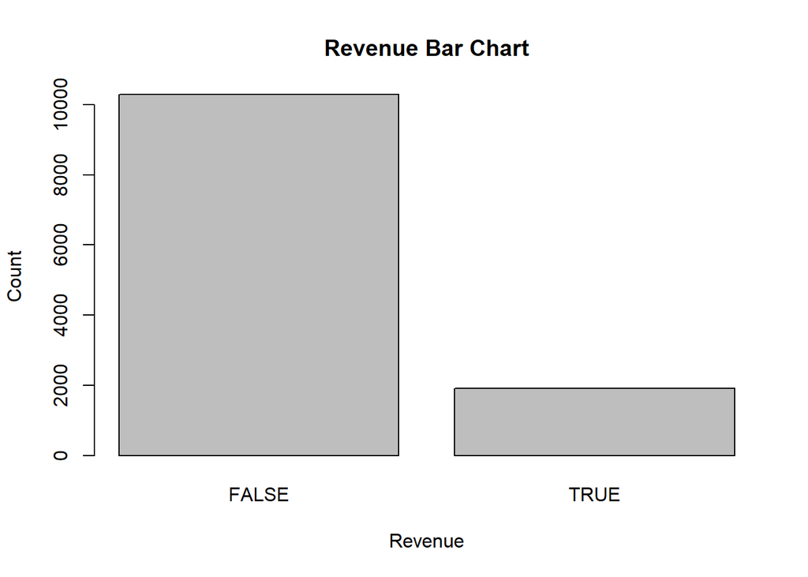

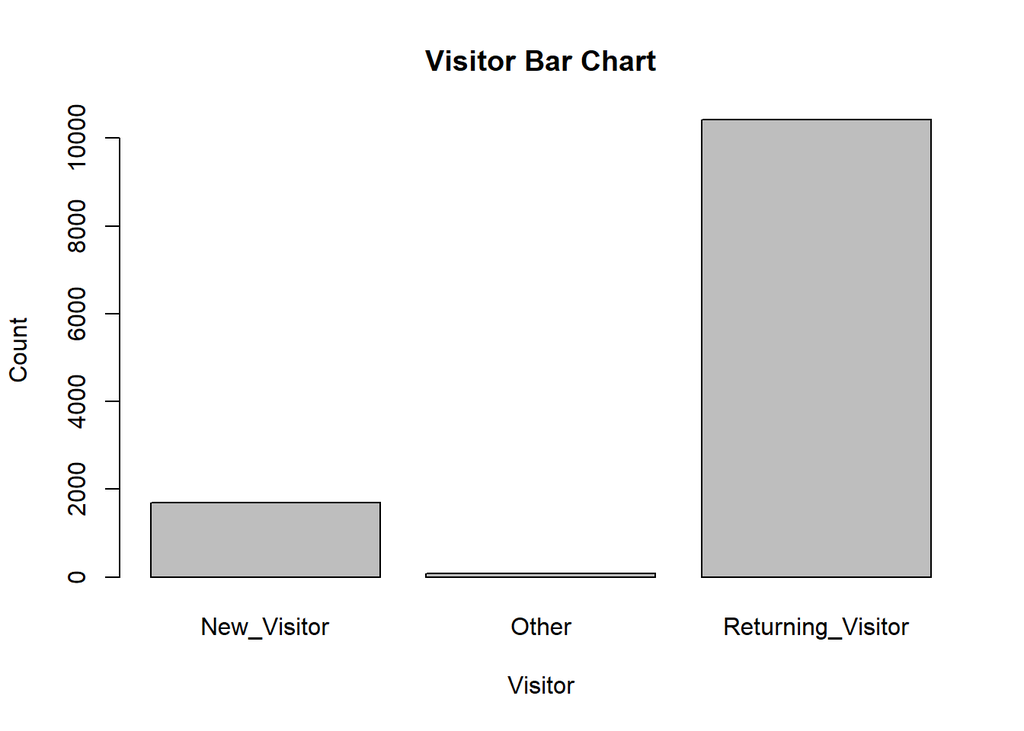

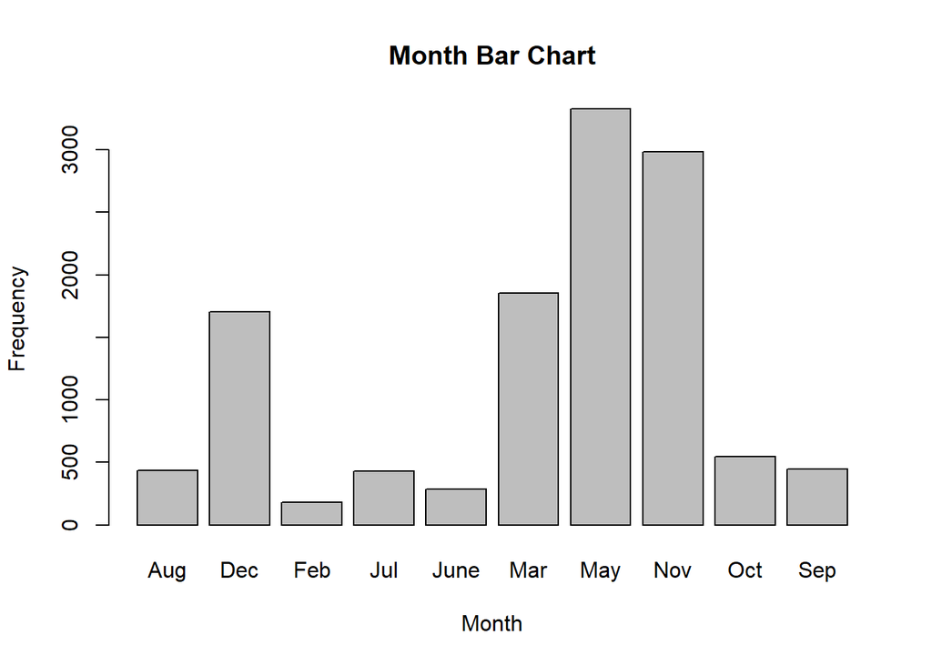

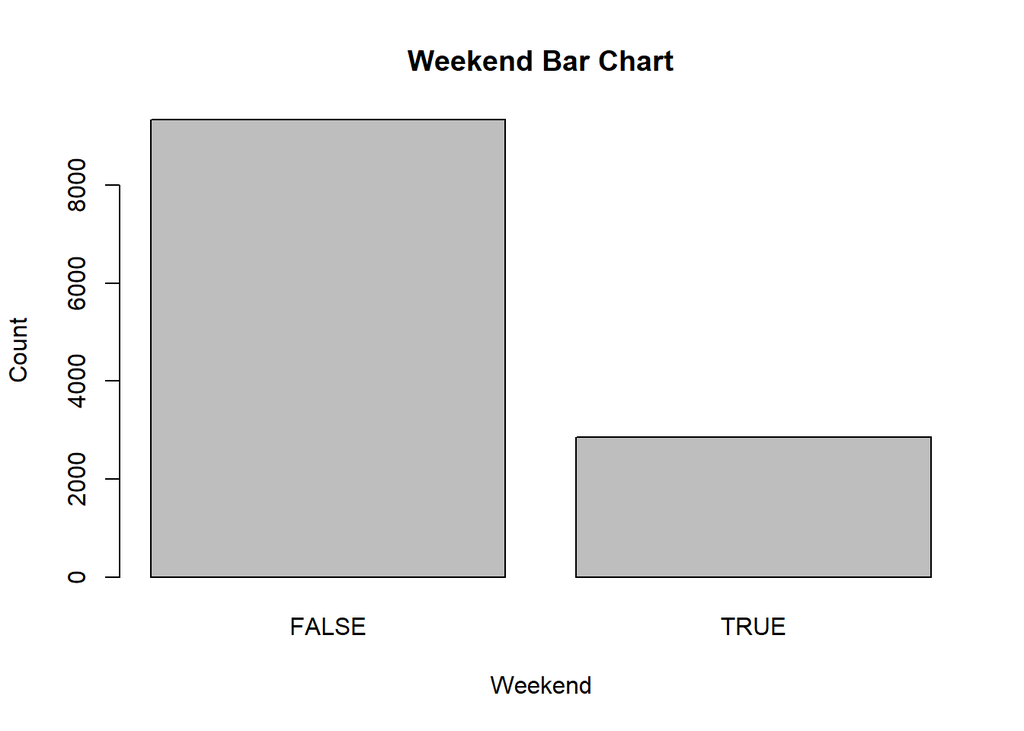

## 2. BIVARIATE DATA ANALYSIS

- First we can create variables that will hold the numerical columns in our dataset.

```r
admin <- new_com$Administrative
addur <- new_com$Administrative_Duration
info <- new_com$Informational
infdur <- new_com$Informational_Duration
prod <- new_com$ProductRelated
prdur <- new_com$ProductRelated_Duration
bounce <- new_com$BounceRates
exit <- new_com$ExitRates
page <- new_com$PageValues
special <- new_com$SpecialDay
```

### Covariance

```r
cov(admin, info)
```

```
## [1] 1.594806
```

There is positive covariance between the administrative and informational columns.

```r
cov(info, prod)
```

```
## [1] 21.20218
```

There is positive covariance between the informational and product related columns.

```r
cov(bounce, exit)
```

```
## [1] 0.001896814
```

- There is a positive covariance between the bounce rates and exit rates columns.

```r
cov(page, special)
```

```
## [1] -0.2404591
```

- There is a negative covariance between the page values and the special day columns.

### Correlation

- The corrplot library allows us to plot a correlation matrix of the numerical columns in our dataset.

```r
library(corrplot)
```

- Plot the correlation map.

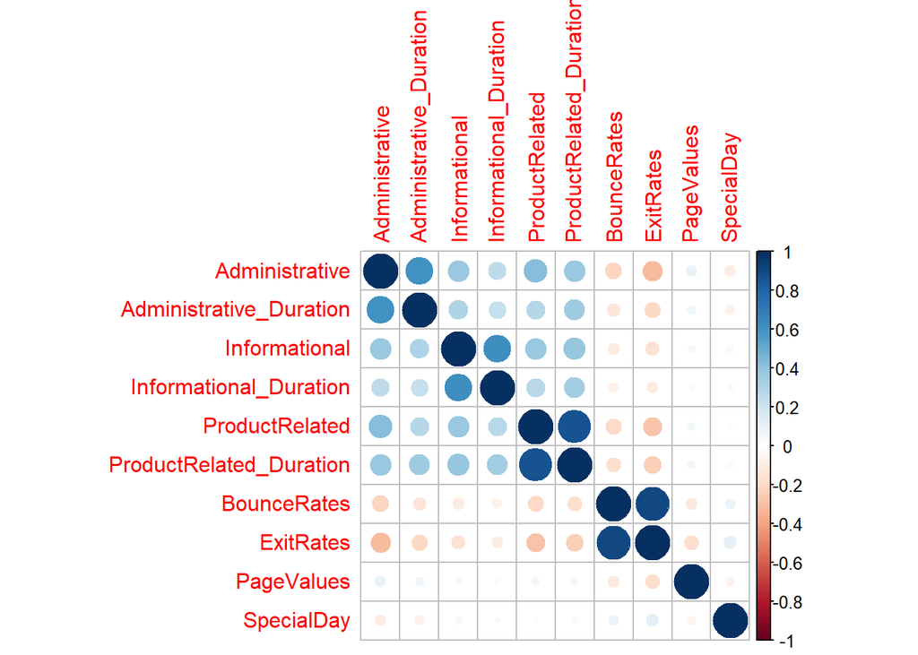

```r
# Correlation matrix
correlation <- cor(numerical_col)
corrplot(correlation)
```

### Scatter Plots

```r
# First we import the ggplot2 library which will help us in visualizations
library(ggplot2)
```

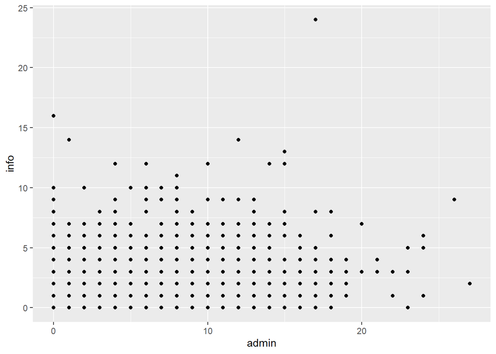

```r
ggplot(new_com, aes(admin, info)) + geom_point()
```

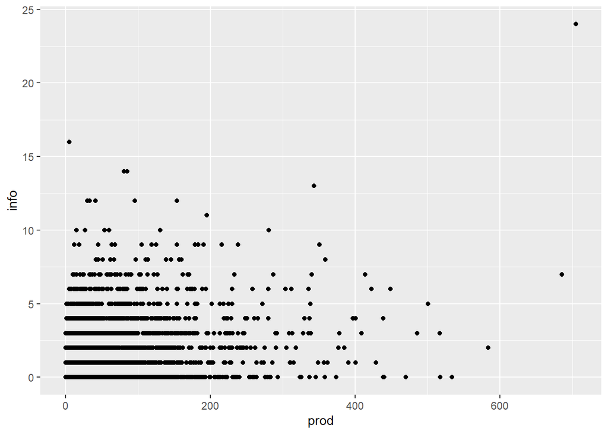

```r
ggplot(new_com, aes(prod, info)) + geom_point()
```

# 7. IMPLEMENTING THE SOLUTION

## 1. K - Means Clustering

- First normalize the data.

```r
# normalizing the data
normalize <- function(x){
  return ((x-min(x)) / (max(x)-min(x)))
}

com.norm <- normalize(numerical_col)
```

- Sample the data to allow clustering since our initial dataset is quite huge.

```r
# this step was added because finding the optimum number of clusters took a while to run. Therefore we take a random sample of 1300 which is around 10% of the initial dataset
Com <- com.norm[sample(nrow(com.norm), size=1300), ]
head(Com)
```

```
##    Administrative Administrative_Duration Informational Informational_Duration
## 1:   2.032059e-04            2.808149e-03  1.563122e-05           1.563122e-05
## 2:   1.406810e-04            7.088759e-03  1.563122e-05           1.563122e-05
## 3:   1.563122e-05            1.563122e-05  1.563122e-05           1.563122e-05
## 4:   1.406810e-04            1.610016e-03  1.563122e-05           1.563122e-05
## 5:   2.657308e-04            3.725702e-03  1.563122e-05           1.563122e-05
## 6:   1.563122e-05            1.563122e-05  1.719434e-04           8.116512e-03
##    ProductRelated ProductRelated_Duration  BounceRates    ExitRates
## 1:   1.219235e-03             0.015631431 1.584438e-05 1.605161e-05
## 2:   4.845679e-04             0.010073281 1.563122e-05 1.592896e-05
## 3:   6.252489e-05             0.002844883 1.667330e-05 1.719434e-05
## 4:   1.313023e-03             0.023393390 1.563122e-05 1.566716e-05
## 5:   7.346675e-04             0.017895145 1.578447e-05 1.585769e-05
## 6:   9.535046e-04             0.032344884 1.567588e-05 1.616361e-05
##      PageValues   SpecialDay
## 1: 9.835187e-05 1.563122e-05
## 2: 1.563122e-05 1.563122e-05
## 3: 1.563122e-05 1.563122e-05
## 4: 1.299325e-03 1.563122e-05
## 5: 1.563122e-05 1.563122e-05
## 6: 1.563122e-05 1.563122e-05
```

- Load the factoextra library which holds the clustering techniques.

```r
# Loading the required libraries
library(factoextra)
library(NbClust)
library (cluster)
```

- Determine the optimal number of k clusters using the elbow method.

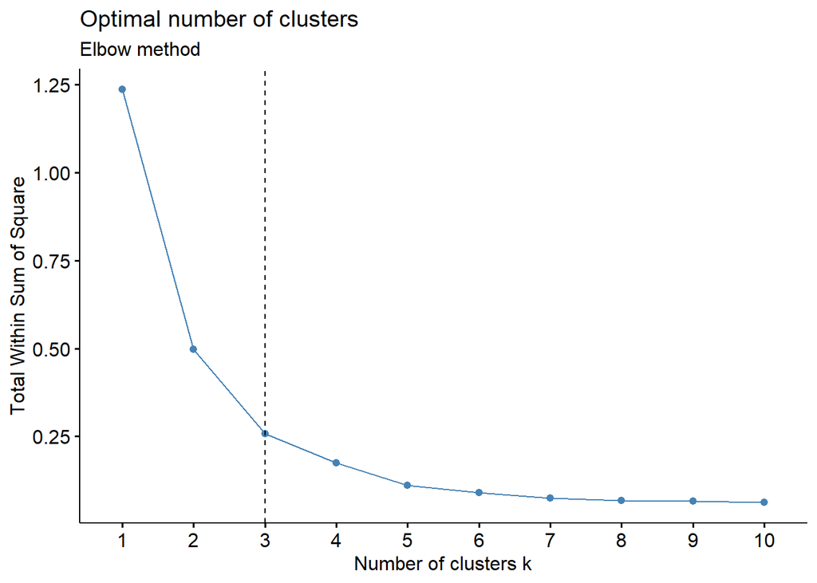

```r
# Elbow method
fviz_nbclust(Com, kmeans, method = "wss") +
            geom_vline(xintercept = 3, linetype = 2)+
            labs(subtitle = "Elbow method")
```

- Using the elbow method, we were able to determine that the optimal number of k in our case is 3.
- We can also dtermine the optimal number of k using the silhouette method and compare with the elbow method.

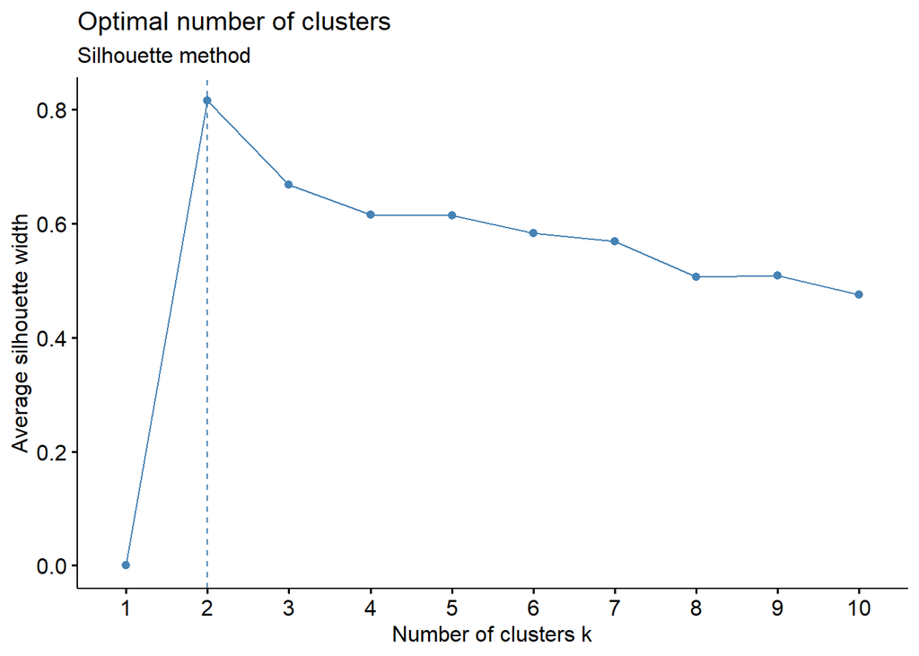

```r
# Silhouette method
fviz_nbclust(Com, kmeans, method = "silhouette")+
  labs(subtitle = "Silhouette method")
```

- Using the silhouette method, we were able to determine that the optimal number of k in our case is 2.
- We can also try using the gap statistic method with nboot set at 500.

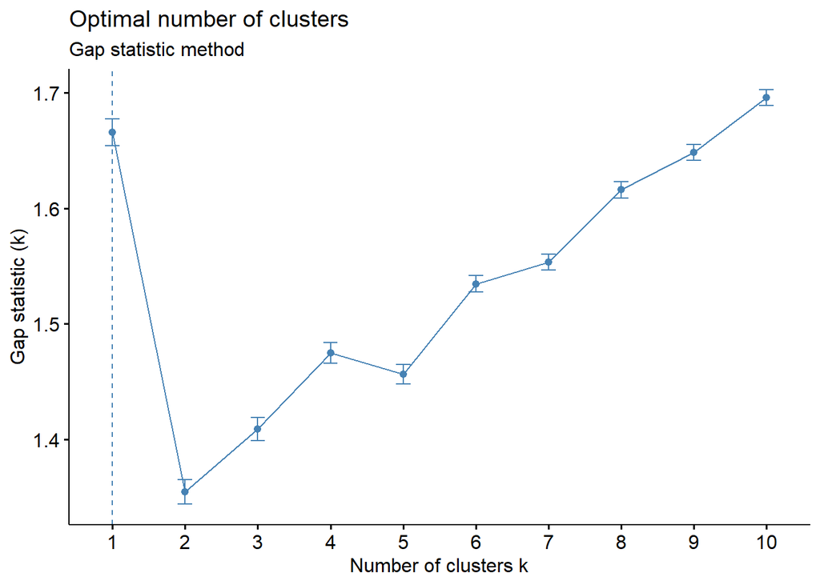

```r
# Gap statistic
# nboot = 50 to keep the function speedy.

set.seed(123)
fviz_nbclust(Com, kmeans, nstart = 25,  method = "gap_stat", nboot = 500)+
  labs(subtitle = "Gap statistic method")
```

- Using the gap statistic method, we find the optimal number of clusters as 1.

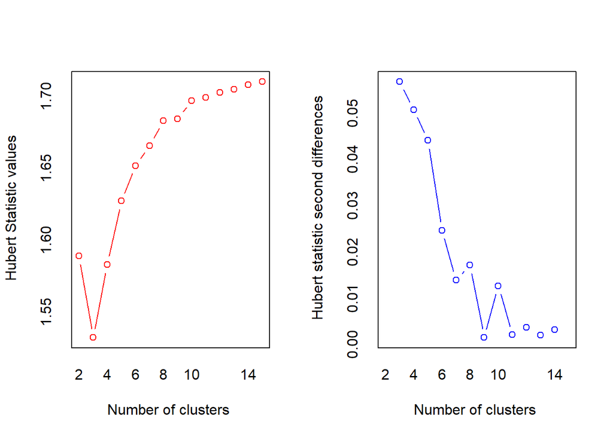

```
## *** : The Hubert index is a graphical method of determining the number of clusters.
##                 In the plot of Hubert index, we seek a significant knee that corresponds to a
##                 significant increase of the value of the measure i.e the significant peak in Hubert
##                 index second differences plot.
##
```

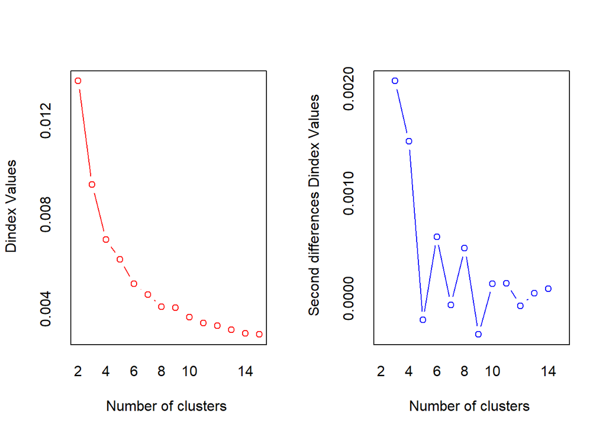

```
## *** : The D index is a graphical method of determining the number of clusters.
##                 In the plot of D index, we seek a significant knee (the significant peak in Dindex
##                 second differences plot) that corresponds to a significant increase of the value of
##                 the measure.
##
## * Among all indices:
## * 9 proposed 2 as the best number of clusters
## * 6 proposed 3 as the best number of clusters
## * 1 proposed 5 as the best number of clusters
## * 3 proposed 7 as the best number of clusters
## * 1 proposed 9 as the best number of clusters
## * 1 proposed 10 as the best number of clusters
## * 1 proposed 11 as the best number of clusters
## * 2 proposed 15 as the best number of clusters
##
##                    ***** Conclusion *****
##
## * According to the majority rule, the best number of clusters is  2
##
##
```

```r
# choosing the best number of clusters
nb<-NbClust(data = Com, distance = "euclidean",
        min.nc = 2, max.nc = 15, method = "kmeans")
```

```
## Among all indices:
## ===================
## * 2 proposed  0 as the best number of clusters
## * 9 proposed  2 as the best number of clusters
## * 6 proposed  3 as the best number of clusters
## * 1 proposed  5 as the best number of clusters
## * 3 proposed  7 as the best number of clusters
## * 1 proposed  9 as the best number of clusters
## * 1 proposed  10 as the best number of clusters
## * 1 proposed  11 as the best number of clusters
## * 2 proposed  15 as the best number of clusters
##
## Conclusion
## =========================
## * According to the majority rule, the best number of clusters is  2 .
```

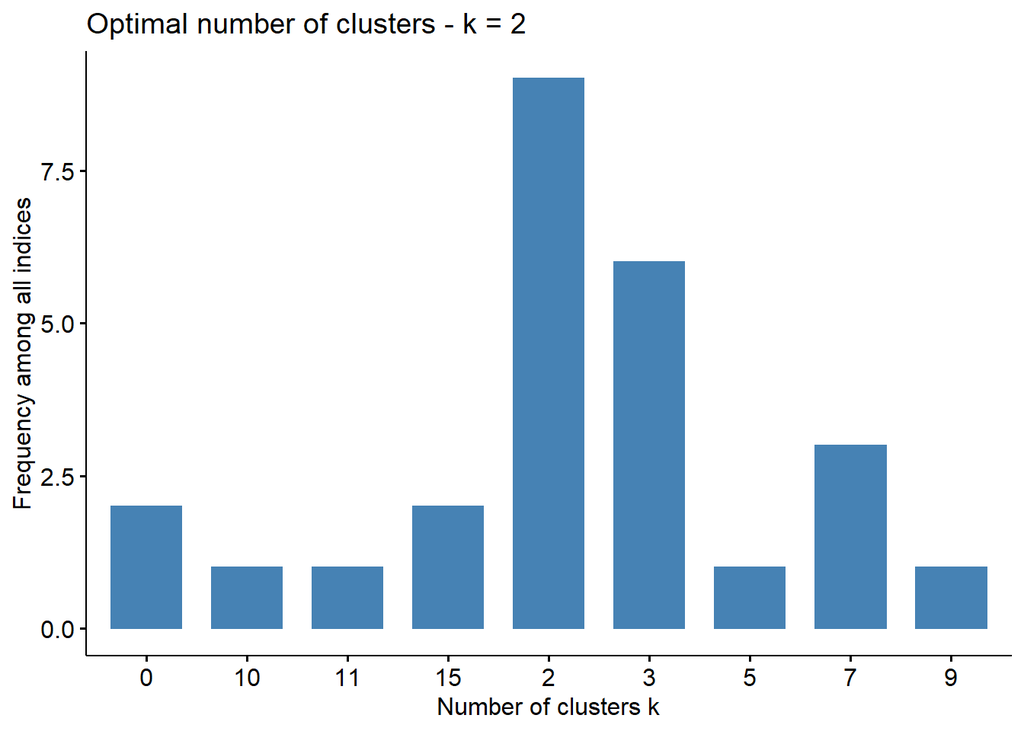

```r
fviz_nbclust(nb)
```

- Fit the kmeans model with our data

```r
km <- kmeans(Com,3,iter.max = 10, nstart = 25)
km
```

```
## K-means clustering with 3 clusters of sizes 1021, 36, 243
##
## Cluster means:
##   Administrative Administrative_Duration Informational Informational_Duration
## 1   4.256102e-05            0.0008533589  2.069874e-05           0.0003525108
## 2   1.493650e-04            0.0041221423  4.428846e-05           0.0019912115
## 3   7.378194e-05            0.0021433966  3.287060e-05           0.0014816893
##   ProductRelated ProductRelated_Duration  BounceRates    ExitRates   PageValues
## 1   0.0003010197             0.008520683 1.599442e-05 1.637029e-05 8.683726e-05
## 2   0.0034093433             0.157004503 1.573358e-05 1.595674e-05 7.946467e-05
## 3   0.0011020977             0.046263385 1.574624e-05 1.598211e-05 1.556039e-04
##     SpecialDay
## 1 1.683457e-05
## 2 1.658646e-05
## 3 1.633881e-05
```

[output cut: 47 more lines]

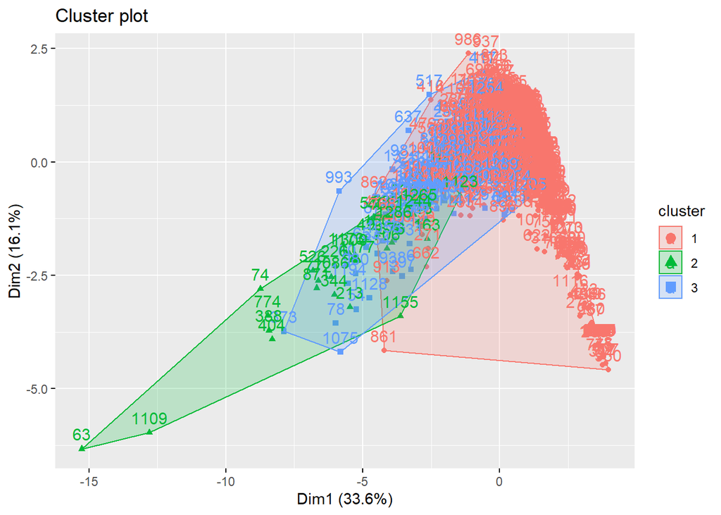

```r
#plot results of final k-means model
fviz_cluster(km, data = Com)
```

### Hierarchical Clustering

- For hierarchical, we first install and load the dplyr package.

```r
# Installing the package
install.packages("dplyr")
# Loading package
library(dplyr)

# Summary of dataset in package
head(Com)
```

```
##    Administrative Administrative_Duration Informational Informational_Duration
## 1:   2.032059e-04            2.808149e-03  1.563122e-05           1.563122e-05
## 2:   1.406810e-04            7.088759e-03  1.563122e-05           1.563122e-05
## 3:   1.563122e-05            1.563122e-05  1.563122e-05           1.563122e-05
## 4:   1.406810e-04            1.610016e-03  1.563122e-05           1.563122e-05
## 5:   2.657308e-04            3.725702e-03  1.563122e-05           1.563122e-05
## 6:   1.563122e-05            1.563122e-05  1.719434e-04           8.116512e-03
##    ProductRelated ProductRelated_Duration  BounceRates    ExitRates
## 1:   1.219235e-03             0.015631431 1.584438e-05 1.605161e-05
## 2:   4.845679e-04             0.010073281 1.563122e-05 1.592896e-05
## 3:   6.252489e-05             0.002844883 1.667330e-05 1.719434e-05
## 4:   1.313023e-03             0.023393390 1.563122e-05 1.566716e-05
## 5:   7.346675e-04             0.017895145 1.578447e-05 1.585769e-05
## 6:   9.535046e-04             0.032344884 1.567588e-05 1.616361e-05
##      PageValues   SpecialDay
## 1: 9.835187e-05 1.563122e-05
## 2: 1.563122e-05 1.563122e-05
## 3: 1.563122e-05 1.563122e-05
## 4: 1.299325e-03 1.563122e-05
## 5: 1.563122e-05 1.563122e-05
## 6: 1.563122e-05 1.563122e-05
```

- Find the euclidean distance matrix in our dataset.

```r
# Finding distance matrix
distance <- dist(Com, method = 'euclidean')
```

- Fit the hierarchical model to our train dataset.

```r
# Fitting Hierarchical clustering Model
# to training dataset
set.seed(240) # Setting seed
Hierar_cl <- hclust(distance, method = "average")
```

- Plot the dendogram of our model.

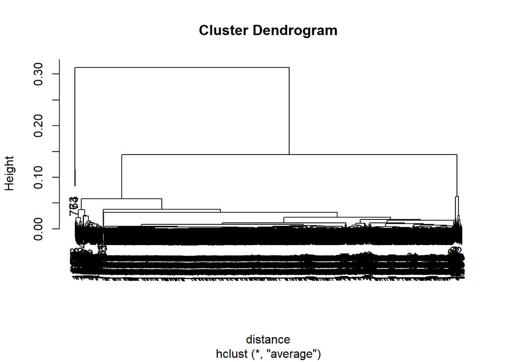

```r
# Plotting dendrogram
plot(Hierar_cl)
```

- Cut the tree by height

```r
# Choosing no. of clusters
# Cutting tree by height
#abline(h = 110, col = "green")
```

- Cutting the tree by the number of clusters.

```r
# Cutting tree by no. of clusters
fit <- cutree(Hierar_cl, k = 3 )
fit
```

[output not shown]

[output cut: 21 more lines]

```r
table(fit)
```

```
## fit
##    1    2    3
## 1273   25    2
```

```r
#rect.hclust(Hierar_cl, k = 3, border = "green")
```

# 8. CHALLENGING THE SOLUTION

```r
# We could challenge the solution by using different numbers of k clusters and compare the results of the algorithms.
# Using the elbow method, we were able to determine that 3 was the optimal number of k clusters in our dataset.
# Using the silhouette method, 2 was the optimal number of k clusters
# Using the gap statistic method, 1 was the optimal number of k clusters.
```

# 9. FOLLOW UP QUESTIONS

## i) Did we have the right data ?

Yes we did as we were also given the variable definitions which helped us understand the dataset better.